# 1. Introdução

Este relatório apresenta uma análise estatística dos dados dos alunos, considerando as variáveis faltas, nota média, turno, escolaridade da mãe e acesso à internet.

O objetivo é realizar uma análise univariada, bivariada e multivariada, buscando identificar possíveis relações entre frequência escolar, desempenho acadêmico e características sociofamiliares.

As variáveis analisadas são:

- faltas: número de faltas do aluno;
- nota_media: nota média do aluno;
- turno: turno em que o aluno estuda;
- escolaridade_mae: escolaridade da mãe;
- acesso_internet: existência ou não de acesso à internet em casa.

# 2. Preparação do ambiente

```r
knitr::opts_chunk$set(
  echo = TRUE,
  message = FALSE,
  warning = FALSE,
  fig.align = "center",
  fig.width = 8,
  fig.height = 5
)

pacotes <- c("ggplot2", "dplyr", "knitr")

instalar <- pacotes[
  !(pacotes %in% installed.packages()[, "Package"])
]

if(length(instalar) > 0){
  install.packages(
    instalar,
    repos = "https://cloud.r-project.org"
  )
}

library(ggplot2)
library(dplyr)
library(knitr)
```

# 3. Importação dos dados

O arquivo `dados_alunos.csv` deve estar na mesma pasta do arquivo `index.Rmd`.

```r
dados_alunos <- read.csv2(
  "dados_alunos.csv",
  header = TRUE,
  stringsAsFactors = FALSE,
  check.names = FALSE,
  na.strings = c("", "NA", "N/A")
)

# Função para converter números
converter_numero <- function(x){

  x <- trimws(as.character(x))

  x <- gsub(" ", "", x)

  # Trata números com vírgula decimal
  x <- gsub(",", ".", x, fixed = TRUE)

  as.numeric(x)
}

# Conversão das variáveis quantitativas

dados_alunos$faltas <- converter_numero(
  dados_alunos$faltas
)

dados_alunos$nota_media <- converter_numero(
  dados_alunos$nota_media
)

# Tratamento das variáveis qualitativas

dados_alunos$turno <- factor(
  trimws(dados_alunos$turno)
)

dados_alunos$escolaridade_mae <- factor(
  trimws(dados_alunos$escolaridade_mae)
)

dados_alunos$acesso_internet <- factor(
  trimws(dados_alunos$acesso_internet)
)
```

# 4. Conferência dos dados

```r
cat("Número de alunos:", nrow(dados_alunos), "\n")
```

```
## Número de alunos: 1000
```

```r
cat(
  "Número de variáveis:",
  ncol(dados_alunos),
  "\n"
)
```

```
## Número de variáveis: 5
```

```r
cat(
  "Tipo da variável faltas:",
  class(dados_alunos$faltas),
  "\n"
)
```

```
## Tipo da variável faltas: numeric
```

```r
cat(
  "Tipo da variável nota_media:",
  class(dados_alunos$nota_media),
  "\n"
)
```

```
## Tipo da variável nota_media: numeric
```

O banco possui 1000 alunos e 5 variáveis.

As variáveis quantitativas foram convertidas para o formato numérico antes da realização dos cálculos estatísticos.

# 5. Primeiros registros

```r
kable(
  head(dados_alunos, 10),
  caption = "Primeiros 10 registros do banco de dados"
)
```

Primeiros 10 registros do banco de dados

| faltas | nota_media | turno | escolaridade_mae | acesso_internet |
| --- | --- | --- | --- | --- |
| 11 | 10.0 | Vespertino | Médio | Sim |
| 8 | 8.3 | Matutino | Fundamental | Sim |
| 9 | 9.2 | Vespertino | Fundamental | Sim |
| 7 | 5.8 | Matutino | Médio | Sim |
| 7 | 8.6 | Vespertino | Fundamental | Não |
| 16 | 5.3 | Vespertino | Médio | Sim |
| 12 | 7.8 | Matutino | Fundamental | Sim |
| 7 | 6.7 | Vespertino | Fundamental | Não |
| 8 | 5.5 | Matutino | Médio | Sim |
| 7 | 7.3 | Noturno | Médio | Sim |

# 6. Análise univariada

## 6.1 Número de faltas

```r
estat_faltas <- data.frame(

  Medida = c(
    "Mínimo",
    "1º Quartil",
    "Mediana",
    "Média",
    "3º Quartil",
    "Máximo",
    "Desvio-padrão"
  ),

  Valor = c(
    min(
      dados_alunos$faltas,
      na.rm = TRUE
    ),

    as.numeric(
      quantile(
        dados_alunos$faltas,
        0.25,
        na.rm = TRUE
      )
    ),

    median(
      dados_alunos$faltas,
      na.rm = TRUE
    ),

    mean(
      dados_alunos$faltas,
      na.rm = TRUE
    ),

    as.numeric(
      quantile(
        dados_alunos$faltas,
        0.75,
        na.rm = TRUE
      )
    ),

    max(
      dados_alunos$faltas,
      na.rm = TRUE
    ),

    sd(
      dados_alunos$faltas,
      na.rm = TRUE
    )
  )
)

kable(
  estat_faltas,
  digits = 2,
  caption = "Estatísticas descritivas do número de faltas"
)
```

Estatísticas descritivas do número de faltas

| Medida | Valor |
| --- | --- |
| Mínimo | 1.00 |
| 1º Quartil | 6.00 |
| Mediana | 8.00 |
| Média | 8.01 |
| 3º Quartil | 10.00 |
| Máximo | 19.00 |
| Desvio-padrão | 2.80 |

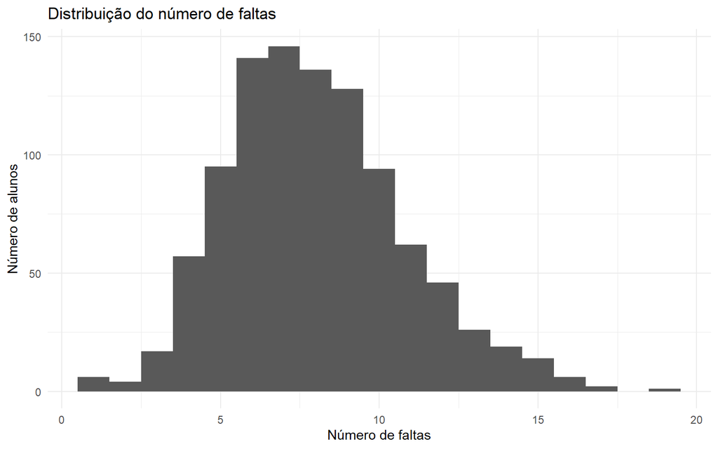

```r
ggplot(
  dados_alunos,
  aes(x = faltas)
) +
  geom_histogram(
    binwidth = 1,
    boundary = -0.5
  ) +
  labs(
    title = "Distribuição do número de faltas",
    x = "Número de faltas",
    y = "Número de alunos"
  ) +
  theme_minimal()
```

A média de faltas é de **8.01**.

A mediana de faltas é de **8**.

## 6.2 Nota média

```r
estat_nota <- data.frame(

  Medida = c(
    "Mínimo",
    "1º Quartil",
    "Mediana",
    "Média",
    "3º Quartil",
    "Máximo",
    "Desvio-padrão"
  ),

  Valor = c(

    min(
      dados_alunos$nota_media,
      na.rm = TRUE
    ),

    as.numeric(
      quantile(
        dados_alunos$nota_media,
        0.25,
        na.rm = TRUE
      )
    ),

    median(
      dados_alunos$nota_media,
      na.rm = TRUE
    ),

    mean(
      dados_alunos$nota_media,
      na.rm = TRUE
    ),

    as.numeric(
      quantile(
        dados_alunos$nota_media,
        0.75,
        na.rm = TRUE
      )
    ),

    max(
      dados_alunos$nota_media,
      na.rm = TRUE
    ),

    sd(
      dados_alunos$nota_media,
      na.rm = TRUE
    )
  )
)

kable(
  estat_nota,
  digits = 2,
  caption = "Estatísticas descritivas da nota média"
)
```

Estatísticas descritivas da nota média

| Medida | Valor |
| --- | --- |
| Mínimo | 0.50 |
| 1º Quartil | 5.20 |
| Mediana | 6.50 |
| Média | 6.44 |
| 3º Quartil | 7.70 |
| Máximo | 10.00 |
| Desvio-padrão | 1.88 |

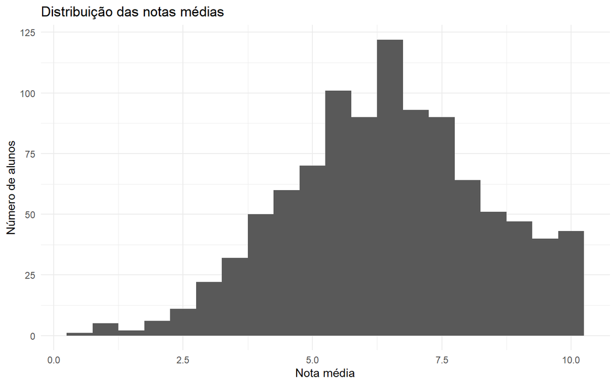

```r
ggplot(
  dados_alunos,
  aes(x = nota_media)
) +
  geom_histogram(
    bins = 20
  ) +
  labs(
    title = "Distribuição das notas médias",
    x = "Nota média",
    y = "Número de alunos"
  ) +
  theme_minimal()
```

A nota média geral dos alunos é de **6.44**.

# 7. Distribuição por turno

```r
tabela_turno <- dados_alunos %>%
  count(turno) %>%
  mutate(
    Percentual = 100 * n / sum(n)
  )

kable(
  tabela_turno,
  digits = 2,
  caption = "Distribuição dos alunos por turno"
)
```

Distribuição dos alunos por turno

| turno | n | Percentual |
| --- | --- | --- |
| Matutino | 451 | 45.1 |
| Noturno | 204 | 20.4 |
| Vespertino | 345 | 34.5 |

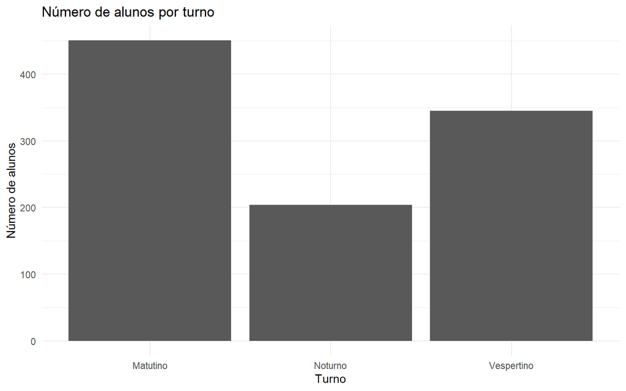

```r
ggplot(
  tabela_turno,
  aes(
    x = turno,
    y = n
  )
) +
  geom_col() +
  labs(
    title = "Número de alunos por turno",
    x = "Turno",
    y = "Número de alunos"
  ) +
  theme_minimal()
```

# 8. Escolaridade da mãe

```r
tabela_escolaridade <- dados_alunos %>%
  count(escolaridade_mae) %>%
  mutate(
    Percentual = 100 * n / sum(n)
  )

kable(
  tabela_escolaridade,
  digits = 2,
  caption = "Distribuição segundo a escolaridade da mãe"
)
```

Distribuição segundo a escolaridade da mãe

| escolaridade_mae | n | Percentual |
| --- | --- | --- |
| Fundamental | 391 | 39.1 |
| Médio | 459 | 45.9 |
| Superior | 150 | 15.0 |

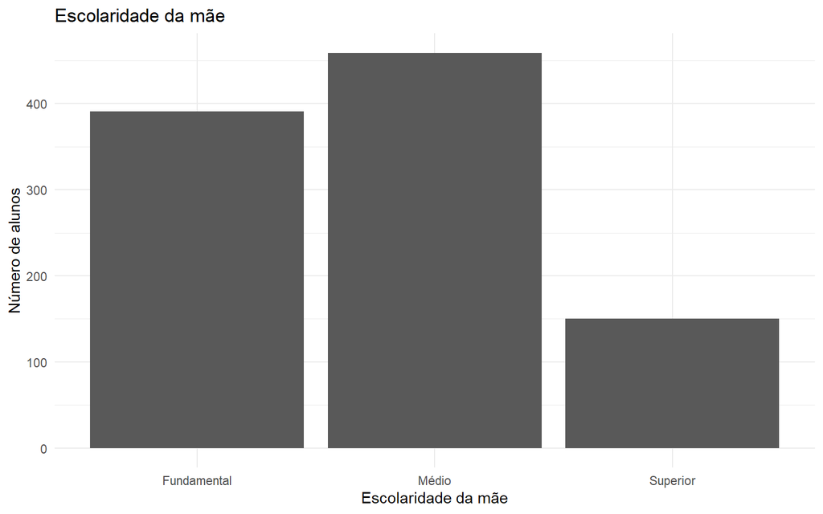

```r
ggplot(
  tabela_escolaridade,
  aes(
    x = escolaridade_mae,
    y = n
  )
) +
  geom_col() +
  labs(
    title = "Escolaridade da mãe",
    x = "Escolaridade da mãe",
    y = "Número de alunos"
  ) +
  theme_minimal()
```

# 9. Acesso à internet

```r
tabela_internet <- dados_alunos %>%
  count(acesso_internet) %>%
  mutate(
    Percentual = 100 * n / sum(n)
  )

kable(
  tabela_internet,
  digits = 2,
  caption = "Acesso à internet em casa"
)
```

Acesso à internet em casa

| acesso_internet | n | Percentual |
| --- | --- | --- |
| Não | 297 | 29.7 |
| Sim | 703 | 70.3 |

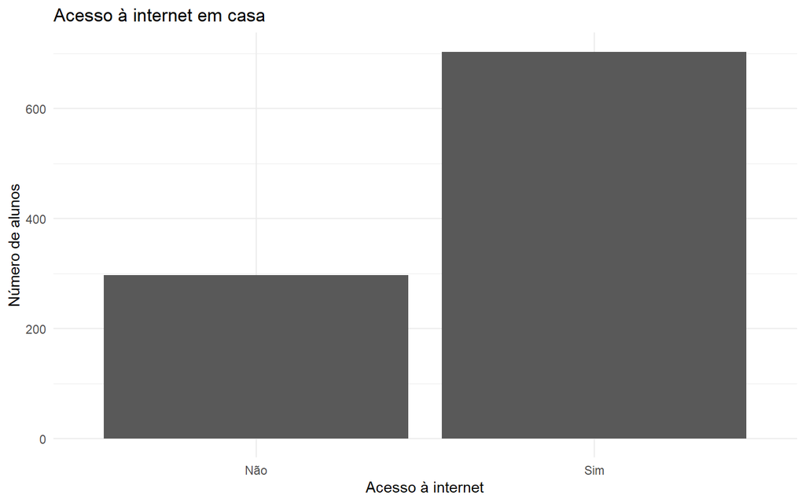

```r
ggplot(
  tabela_internet,
  aes(
    x = acesso_internet,
    y = n
  )
) +
  geom_col() +
  labs(
    title = "Acesso à internet em casa",
    x = "Acesso à internet",
    y = "Número de alunos"
  ) +
  theme_minimal()
```

# 10. Questão 1 - Acesso à internet e desempenho

**Pergunta:** Alunos com acesso à internet em casa apresentam notas médias significativamente maiores?

```r
q1 <- dados_alunos %>%
  group_by(acesso_internet) %>%
  summarise(
    N = n(),
    Media = mean(
      nota_media,
      na.rm = TRUE
    ),
    Desvio_Padrao = sd(
      nota_media,
      na.rm = TRUE
    ),
    Mediana = median(
      nota_media,
      na.rm = TRUE
    ),
    .groups = "drop"
  )

kable(
  q1,
  digits = 2,
  caption = "Notas segundo o acesso à internet"
)
```

Notas segundo o acesso à internet

| acesso_internet | N | Media | Desvio_Padrao | Mediana |
| --- | --- | --- | --- | --- |
| Não | 297 | 6.48 | 1.90 | 6.5 |
| Sim | 703 | 6.43 | 1.87 | 6.5 |

```r
teste_internet <- t.test(
  nota_media ~ acesso_internet,
  data = dados_alunos
)

p_internet <- teste_internet$p.value
```

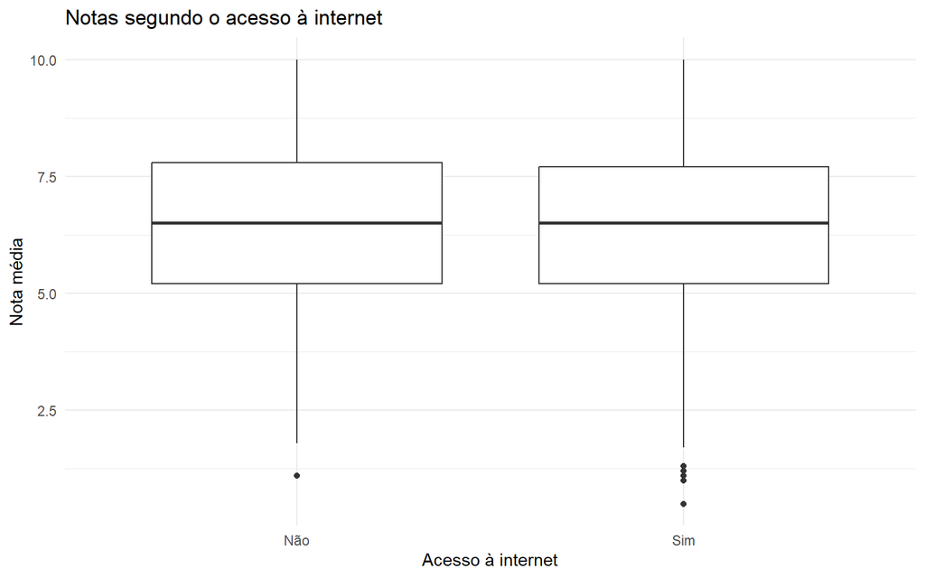

```r
ggplot(
  dados_alunos,
  aes(
    x = acesso_internet,
    y = nota_media
  )
) +
  geom_boxplot() +
  labs(
    title = "Notas segundo o acesso à internet",
    x = "Acesso à internet",
    y = "Nota média"
  ) +
  theme_minimal()
```

## Resposta

A média das notas por grupo é apresentada na tabela acima.

O teste t apresentou p-valor igual a **0.6802**.

Considerando nível de significância de 5%, não há evidências estatísticas suficientes de diferença significativa entre as médias das notas dos alunos com e sem acesso à internet.

# 11. Questão 2 - Escolaridade da mãe e desempenho

**Pergunta:** Como a escolaridade da mãe se relaciona com o desempenho dos alunos?

```r
q2 <- dados_alunos %>%
  group_by(escolaridade_mae) %>%
  summarise(
    N = n(),
    Media = mean(
      nota_media,
      na.rm = TRUE
    ),
    Mediana = median(
      nota_media,
      na.rm = TRUE
    ),
    Desvio_Padrao = sd(
      nota_media,
      na.rm = TRUE
    ),
    .groups = "drop"
  )

kable(
  q2,
  digits = 2,
  caption = "Desempenho segundo escolaridade da mãe"
)
```

Desempenho segundo escolaridade da mãe

| escolaridade_mae | N | Media | Mediana | Desvio_Padrao |
| --- | --- | --- | --- | --- |
| Fundamental | 391 | 6.33 | 6.5 | 1.85 |
| Médio | 459 | 6.55 | 6.5 | 1.85 |
| Superior | 150 | 6.41 | 6.2 | 2.05 |

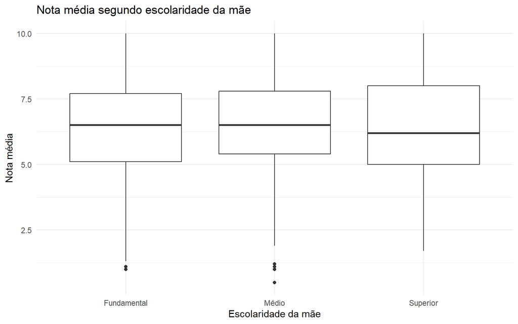

```r
ggplot(
  dados_alunos,
  aes(
    x = escolaridade_mae,
    y = nota_media
  )
) +
  geom_boxplot() +
  labs(
    title = "Nota média segundo escolaridade da mãe",
    x = "Escolaridade da mãe",
    y = "Nota média"
  ) +
  theme_minimal()
```

```r
modelo_escolaridade <- aov(
  nota_media ~ escolaridade_mae,
  data = dados_alunos
)

p_anova <- summary(
  modelo_escolaridade
)[[1]][["Pr(>F)"]][1]
```

## Resposta

As médias das notas para os diferentes níveis de escolaridade da mãe estão apresentadas na tabela.

A ANOVA apresentou p-valor igual a **0.2133**.

Assim, considerando 5% de significância, não há evidências estatísticas suficientes para afirmar que as médias das notas sejam diferentes segundo a escolaridade da mãe.

# 12. Questão 3 - Faltas e desempenho

**Pergunta:** Qual é a correlação entre número de faltas e nota média? Existe um ponto crítico a partir do qual as faltas comprometem severamente o desempenho?

```r
correlacao <- cor(
  dados_alunos$faltas,
  dados_alunos$nota_media,
  use = "complete.obs",
  method = "pearson"
)

teste_cor <- cor.test(
  dados_alunos$faltas,
  dados_alunos$nota_media,
  method = "pearson"
)

p_cor <- teste_cor$p.value
```

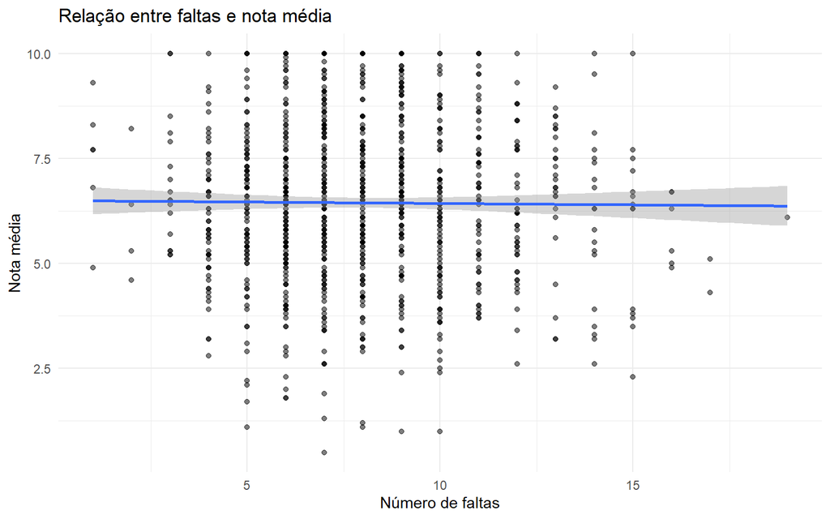

```r
ggplot(
  dados_alunos,
  aes(
    x = faltas,
    y = nota_media
  )
) +
  geom_point(
    alpha = 0.5
  ) +
  geom_smooth(
    method = "lm",
    se = TRUE
  ) +
  labs(
    title = "Relação entre faltas e nota média",
    x = "Número de faltas",
    y = "Nota média"
  ) +
  theme_minimal()
```

## Resposta

O coeficiente de correlação de Pearson foi **-0.01**.

O p-valor foi **0.7506**.

A correlação observada é negativa.

Para verificar possíveis faixas de faltas:

```r
dados_alunos$faixa_faltas <- cut(
  dados_alunos$faltas,
  breaks = c(
    -Inf,
    5,
    10,
    15,
    20,
    25,
    Inf
  ),
  labels = c(
    "Até 5",
    "6 a 10",
    "11 a 15",
    "16 a 20",
    "21 a 25",
    "Mais de 25"
  )
)

q3_faixas <- dados_alunos %>%
  group_by(faixa_faltas) %>%
  summarise(
    N = n(),
    Media_Nota = mean(
      nota_media,
      na.rm = TRUE
    ),
    .groups = "drop"
  )

kable(
  q3_faixas,
  digits = 2,
  caption = "Nota média segundo faixa de faltas"
)
```

Nota média segundo faixa de faltas

| faixa_faltas | N | Media_Nota |
| --- | --- | --- |
| Até 5 | 179 | 6.37 |
| 6 a 10 | 645 | 6.47 |
| 11 a 15 | 167 | 6.46 |
| 16 a 20 | 9 | 5.60 |

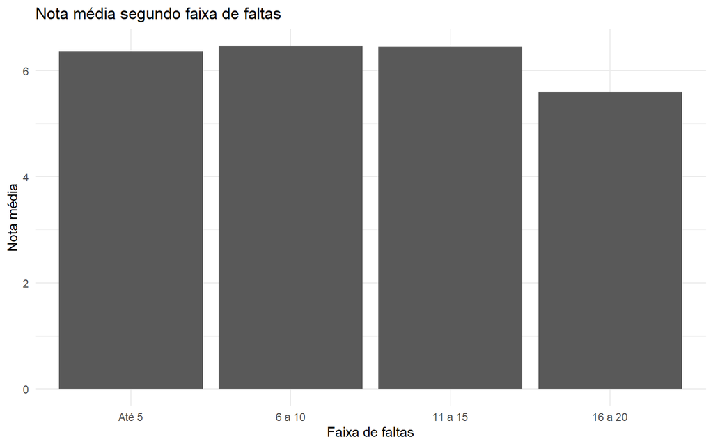

```r
ggplot(
  q3_faixas,
  aes(
    x = faixa_faltas,
    y = Media_Nota
  )
) +
  geom_col() +
  labs(
    title = "Nota média segundo faixa de faltas",
    x = "Faixa de faltas",
    y = "Nota média"
  ) +
  theme_minimal()
```

A tabela e o gráfico permitem identificar se existe redução do desempenho conforme aumentam as faltas. Um possível ponto crítico deve ser interpretado como um padrão específico deste banco de dados, e não como uma regra geral.

# 13. Questão 4 - Perfil do aluno do turno noturno

**Pergunta:** Alunos do turno noturno têm mais faltas? Como seu desempenho se compara aos demais turnos?

```r
q4 <- dados_alunos %>%
  group_by(turno) %>%
  summarise(
    N = n(),
    Media_Faltas = mean(
      faltas,
      na.rm = TRUE
    ),
    Mediana_Faltas = median(
      faltas,
      na.rm = TRUE
    ),
    Media_Nota = mean(
      nota_media,
      na.rm = TRUE
    ),
    Mediana_Nota = median(
      nota_media,
      na.rm = TRUE
    ),
    .groups = "drop"
  )

kable(
  q4,
  digits = 2,
  caption = "Faltas e desempenho segundo o turno"
)
```

Faltas e desempenho segundo o turno

| turno | N | Media_Faltas | Mediana_Faltas | Media_Nota | Mediana_Nota |
| --- | --- | --- | --- | --- | --- |
| Matutino | 451 | 8.03 | 8 | 6.46 | 6.5 |
| Noturno | 204 | 7.95 | 8 | 6.58 | 6.7 |
| Vespertino | 345 | 8.03 | 8 | 6.34 | 6.4 |

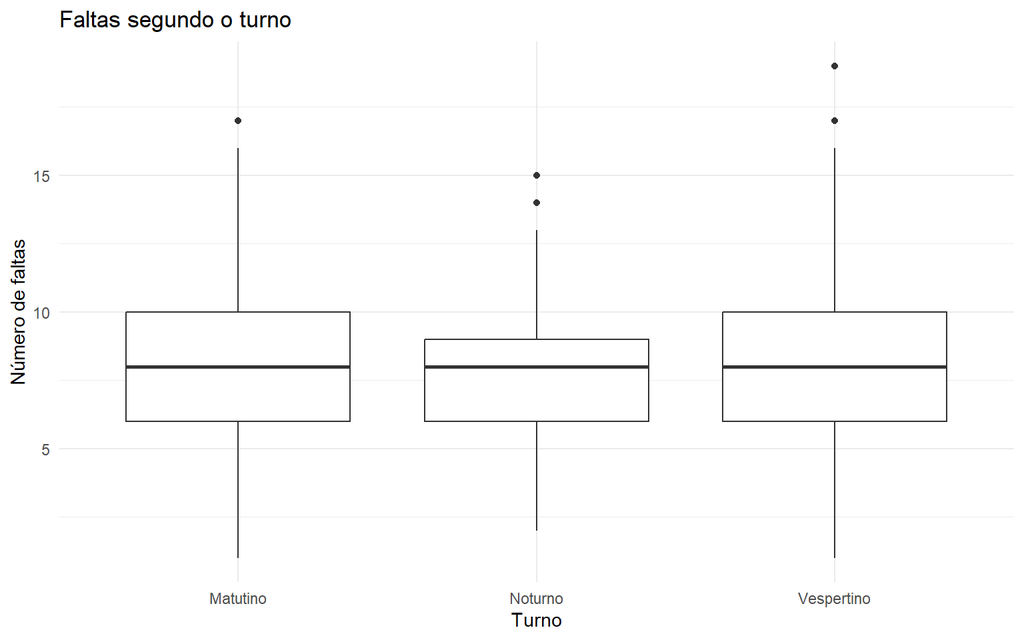

```r
ggplot(
  dados_alunos,
  aes(
    x = turno,
    y = faltas
  )
) +
  geom_boxplot() +
  labs(
    title = "Faltas segundo o turno",
    x = "Turno",
    y = "Número de faltas"
  ) +
  theme_minimal()
```

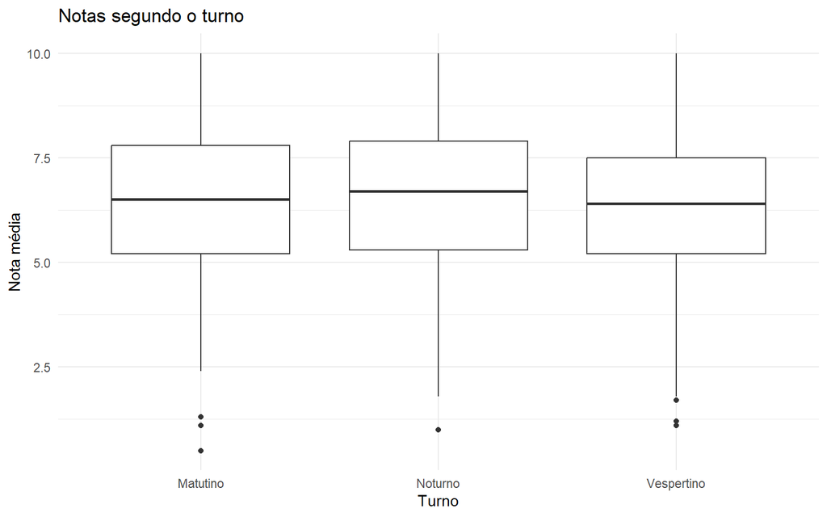

```r
ggplot(
  dados_alunos,
  aes(
    x = turno,
    y = nota_media
  )
) +
  geom_boxplot() +
  labs(
    title = "Notas segundo o turno",
    x = "Turno",
    y = "Nota média"
  ) +
  theme_minimal()
```

```r
anova_faltas <- aov(
  faltas ~ turno,
  data = dados_alunos
)

anova_notas <- aov(
  nota_media ~ turno,
  data = dados_alunos
)

p_turno_faltas <- summary(
  anova_faltas
)[[1]][["Pr(>F)"]][1]

p_turno_notas <- summary(
  anova_notas
)[[1]][["Pr(>F)"]][1]

media_faltas_noturno <- q4$Media_Faltas[
  q4$turno == "Noturno"
]

media_nota_noturno <- q4$Media_Nota[
  q4$turno == "Noturno"
]

media_faltas_outros <- mean(
  dados_alunos$faltas[
    dados_alunos$turno != "Noturno"
  ],
  na.rm = TRUE
)

media_nota_outros <- mean(
  dados_alunos$nota_media[
    dados_alunos$turno != "Noturno"
  ],
  na.rm = TRUE
)
```

## Resposta

A média de faltas dos alunos do turno noturno é **7.95**.

A média dos demais turnos é **8.03**.

Portanto, os alunos do noturno não apresentam maior número médio de faltas.

A média das notas do noturno é **6.58**, enquanto a média dos demais turnos é **6.41**.

A ANOVA para faltas apresentou p-valor de **0.9289**.

A ANOVA para notas apresentou p-valor de **0.3191**.

# 14. Questão 5 - Desigualdades educacionais

**Pergunta:** As variáveis sociofamiliares escolaridade da mãe e acesso à internet explicam parte da variabilidade no desempenho dos alunos?

```r
modelo <- lm(
  nota_media ~ escolaridade_mae + acesso_internet,
  data = dados_alunos
)

sumario_modelo <- summary(
  modelo
)

r2 <- sumario_modelo$r.squared

r2_ajustado <- sumario_modelo$adj.r.squared

coeficientes <- as.data.frame(
  coef(sumario_modelo)
)

kable(
  coeficientes,
  digits = 4,
  caption = "Coeficientes do modelo de regressão"
)
```

Coeficientes do modelo de regressão

|  | Estimate | Std. Error | t value | Pr(>\|t\|) |
| --- | --- | --- | --- | --- |
| (Intercept) | 6.3731 | 0.1311 | 48.6229 | 0.0000 |
| escolaridade_maeMédio | 0.2280 | 0.1296 | 1.7586 | 0.0789 |
| escolaridade_maeSuperior | 0.0772 | 0.1808 | 0.4269 | 0.6695 |
| acesso_internetSim | -0.0648 | 0.1305 | -0.4964 | 0.6197 |

```r
kable(
  anova(modelo),
  digits = 4,
  caption = "Análise de variância do modelo"
)
```

Análise de variância do modelo

|  | Df | Sum Sq | Mean Sq | F value | Pr(>F) |
| --- | --- | --- | --- | --- | --- |
| escolaridade_mae | 2 | 10.9554 | 5.4777 | 1.5463 | 0.2135 |
| acesso_internet | 1 | 0.8730 | 0.8730 | 0.2464 | 0.6197 |
| Residuals | 996 | 3528.2931 | 3.5425 | NA | NA |

## Resposta

O modelo apresentou **R² = 0.003**.

Isso significa que aproximadamente **0.3%** da variabilidade das notas é explicada conjuntamente pelas variáveis escolaridade da mãe e acesso à internet dentro deste modelo.

O R² ajustado foi **0**.

Assim, o modelo apresenta baixo poder explicativo sobre a variação das notas.

É importante lembrar que associação estatística não significa necessariamente causalidade.

# 15. Questão 6 - Turno e acesso à internet

**Pergunta:** Considerando conjuntamente turno e acesso à internet, que padrões emergem?

```r
q6 <- dados_alunos %>%
  group_by(
    turno,
    acesso_internet
  ) %>%
  summarise(
    N = n(),
    Media_Faltas = mean(
      faltas,
      na.rm = TRUE
    ),
    Media_Nota = mean(
      nota_media,
      na.rm = TRUE
    ),
    .groups = "drop"
  )

kable(
  q6,
  digits = 2,
  caption = "Desempenho segundo turno e acesso à internet"
)
```

Desempenho segundo turno e acesso à internet

| turno | acesso_internet | N | Media_Faltas | Media_Nota |
| --- | --- | --- | --- | --- |
| Matutino | Não | 133 | 7.90 | 6.54 |
| Matutino | Sim | 318 | 8.09 | 6.43 |
| Noturno | Não | 57 | 7.58 | 6.86 |
| Noturno | Sim | 147 | 8.09 | 6.48 |
| Vespertino | Não | 107 | 7.58 | 6.21 |
| Vespertino | Sim | 238 | 8.23 | 6.40 |

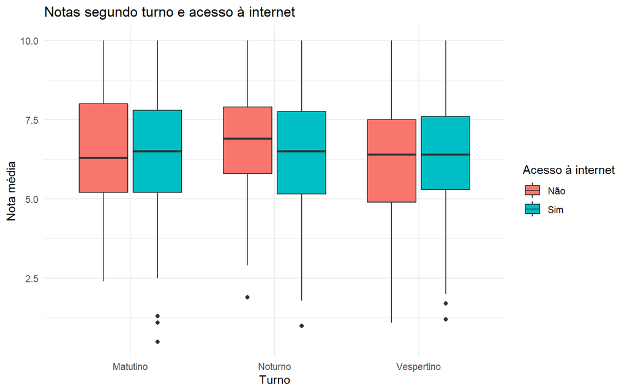

```r
ggplot(
  dados_alunos,
  aes(
    x = turno,
    y = nota_media,
    fill = acesso_internet
  )
) +
  geom_boxplot() +
  labs(
    title = "Notas segundo turno e acesso à internet",
    x = "Turno",
    y = "Nota média",
    fill = "Acesso à internet"
  ) +
  theme_minimal()
```

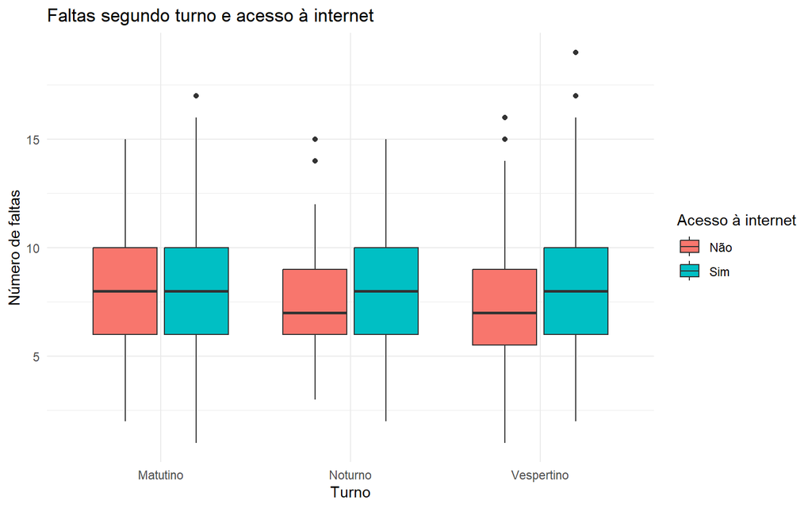

```r
ggplot(
  dados_alunos,
  aes(
    x = turno,
    y = faltas,
    fill = acesso_internet
  )
) +
  geom_boxplot() +
  labs(
    title = "Faltas segundo turno e acesso à internet",
    x = "Turno",
    y = "Número de faltas",
    fill = "Acesso à internet"
  ) +
  theme_minimal()
```

```r
melhor_grupo <- q6 %>%
  filter(
    !is.na(Media_Nota)
  ) %>%
  slice_max(
    Media_Nota,
    n = 1,
    with_ties = FALSE
  )

pior_grupo <- q6 %>%
  filter(
    !is.na(Media_Nota)
  ) %>%
  slice_min(
    Media_Nota,
    n = 1,
    with_ties = FALSE
  )
```

## Resposta

O grupo com maior nota média foi o turno **Noturno**, com acesso à internet **Não**, apresentando nota média de **6.86**.

O grupo com menor nota média foi o turno **Vespertino**, com acesso à internet **Não**, apresentando nota média de **6.21**.

A análise conjunta mostra que o comportamento do desempenho pode variar de acordo com a combinação entre turno e acesso à internet.

# 16. Síntese dos resultados

```r
resumo <- data.frame(

  Questao = c(
    "1 - Internet e desempenho",
    "2 - Escolaridade da mãe",
    "3 - Faltas e desempenho",
    "4 - Turno",
    "5 - Variáveis sociofamiliares",
    "6 - Turno e internet"
  ),

  Resultado = c(

    paste0(
      "Média com internet = ",
      round(
        mean(
          dados_alunos$nota_media[
            dados_alunos$acesso_internet ==
              levels(dados_alunos$acesso_internet)[
                length(levels(dados_alunos$acesso_internet))
              ]
          ],
          na.rm = TRUE
        ),
        2
      ),
      "; p = ",
      format.pval(
        p_internet,
        digits = 3
      )
    ),

    paste0(
      "ANOVA p = ",
      format.pval(
        p_anova,
        digits = 3
      )
    ),

    paste0(
      "Correlação = ",
      round(
        correlacao,
        3
      ),
      "; p = ",
      format.pval(
        p_cor,
        digits = 3
      )
    ),

    paste0(
      "Noturno: faltas = ",
      round(
        media_faltas_noturno,
        2
      ),
      "; nota = ",
      round(
        media_nota_noturno,
        2
      )
    ),

    paste0(
      "R² = ",
      round(
        r2,
        3
      ),
      " (",
      round(
        100*r2,
        1
      ),
      "%)"
    ),

    paste0(
      "Maior média = ",
      melhor_grupo$turno,
      " / ",
      melhor_grupo$acesso_internet,
      " (",
      round(
        melhor_grupo$Media_Nota,
        2
      ),
      ")"
    )
  )
)

kable(
  resumo,
  caption = "Síntese dos principais resultados"
)
```

Síntese dos principais resultados

| Questao | Resultado |
| --- | --- |
| 1 - Internet e desempenho | Média com internet = 6.43; p = 0.68 |
| 2 - Escolaridade da mãe | ANOVA p = 0.213 |
| 3 - Faltas e desempenho | Correlação = -0.01; p = 0.751 |
| 4 - Turno | Noturno: faltas = 7.95; nota = 6.58 |
| 5 - Variáveis sociofamiliares | R² = 0.003 (0.3%) |
| 6 - Turno e internet | Maior média = Noturno / Não (6.86) |

# 17. Conclusão

A análise estatística realizada permitiu investigar as relações entre frequência escolar, desempenho acadêmico e características sociofamiliares.

A análise univariada possibilitou conhecer a distribuição das variáveis quantitativas e qualitativas por meio de medidas descritivas, tabelas e gráficos.

A análise bivariada permitiu investigar as relações entre acesso à internet e desempenho, escolaridade da mãe e desempenho, faltas e notas e diferenças entre os turnos.

A análise multivariada permitiu avaliar conjuntamente o papel da escolaridade da mãe e do acesso à internet na explicação da variabilidade das notas.

Os resultados devem ser interpretados considerando as características específicas do banco de dados.

Uma associação estatística não deve ser interpretada automaticamente como uma relação de causa e efeito.

# 18. Limitações

O banco de dados contém um conjunto limitado de variáveis. O desempenho escolar pode depender de diversos outros fatores que não foram considerados na análise.

Entre possíveis variáveis adicionais estão renda familiar, tempo dedicado aos estudos, participação dos responsáveis, situação de trabalho do aluno, transporte, acesso a materiais escolares e características da escola.

Além disso, os resultados representam associações observadas nos dados e não permitem, isoladamente, estabelecer relações causais.

# 19. Considerações finais

O uso do RStudio possibilitou realizar uma análise estatística reprodutível, incluindo importação e tratamento dos dados, estatística descritiva, tabelas, gráficos, testes de hipóteses, correlação e regressão linear.

As seis questões propostas foram analisadas com base nos dados disponíveis.